# Risk Factor Analysis

## Outcome Variable

**Outcome Variable:** ever_stunted

## Predictor Variables

**Intervention Variable:** gagebrth

**Adjustment Set:**

unadjusted

## Stratifying Variables

The analysis was stratified on these variable(s):

- agecat
- studyid
- country

## Data Summary

| agecat | studyid | country | gagebrth | ever_stunted | n_cell | n |
| --- | --- | --- | --- | --- | --- | --- |
| 0-24 months (no birth st.) | CMC-V-BCS-2002 | INDIA | Full or late term | 0 | 18 | 278 |
| 0-24 months (no birth st.) | CMC-V-BCS-2002 | INDIA | Full or late term | 1 | 164 | 278 |
| 0-24 months (no birth st.) | CMC-V-BCS-2002 | INDIA | Preterm | 0 | 3 | 278 |
| 0-24 months (no birth st.) | CMC-V-BCS-2002 | INDIA | Preterm | 1 | 30 | 278 |
| 0-24 months (no birth st.) | CMC-V-BCS-2002 | INDIA | Early term | 0 | 7 | 278 |
| 0-24 months (no birth st.) | CMC-V-BCS-2002 | INDIA | Early term | 1 | 56 | 278 |
| 0-24 months (no birth st.) | COHORTS | GUATEMALA | Full or late term | 0 | 94 | 694 |
| 0-24 months (no birth st.) | COHORTS | GUATEMALA | Full or late term | 1 | 303 | 694 |
| 0-24 months (no birth st.) | COHORTS | GUATEMALA | Preterm | 0 | 23 | 694 |
| 0-24 months (no birth st.) | COHORTS | GUATEMALA | Preterm | 1 | 79 | 694 |
| 0-24 months (no birth st.) | COHORTS | GUATEMALA | Early term | 0 | 41 | 694 |
| 0-24 months (no birth st.) | COHORTS | GUATEMALA | Early term | 1 | 154 | 694 |
| 0-24 months (no birth st.) | COHORTS | INDIA | Full or late term | 0 | 395 | 1238 |
| 0-24 months (no birth st.) | COHORTS | INDIA | Full or late term | 1 | 160 | 1238 |
| 0-24 months (no birth st.) | COHORTS | INDIA | Preterm | 0 | 181 | 1238 |
| 0-24 months (no birth st.) | COHORTS | INDIA | Preterm | 1 | 88 | 1238 |
| 0-24 months (no birth st.) | COHORTS | INDIA | Early term | 0 | 290 | 1238 |
| 0-24 months (no birth st.) | COHORTS | INDIA | Early term | 1 | 124 | 1238 |
| 0-24 months (no birth st.) | COHORTS | PHILIPPINES | Full or late term | 0 | 395 | 2846 |
| 0-24 months (no birth st.) | COHORTS | PHILIPPINES | Full or late term | 1 | 735 | 2846 |
| 0-24 months (no birth st.) | COHORTS | PHILIPPINES | Preterm | 0 | 185 | 2846 |
| 0-24 months (no birth st.) | COHORTS | PHILIPPINES | Preterm | 1 | 380 | 2846 |
| 0-24 months (no birth st.) | COHORTS | PHILIPPINES | Early term | 0 | 370 | 2846 |
| 0-24 months (no birth st.) | COHORTS | PHILIPPINES | Early term | 1 | 781 | 2846 |
| 0-24 months (no birth st.) | IRC | INDIA | Full or late term | 0 | 95 | 341 |
| 0-24 months (no birth st.) | IRC | INDIA | Full or late term | 1 | 126 | 341 |
| 0-24 months (no birth st.) | IRC | INDIA | Preterm | 0 | 9 | 341 |
| 0-24 months (no birth st.) | IRC | INDIA | Preterm | 1 | 23 | 341 |
| 0-24 months (no birth st.) | IRC | INDIA | Early term | 0 | 34 | 341 |
| 0-24 months (no birth st.) | IRC | INDIA | Early term | 1 | 54 | 341 |

[output cut: 132 more lines]

The following strata were considered:

- agecat: 0-24 months (no birth st.), studyid: CMC-V-BCS-2002, country: INDIA
- agecat: 0-24 months (no birth st.), studyid: COHORTS, country: GUATEMALA
- agecat: 0-24 months (no birth st.), studyid: COHORTS, country: INDIA
- agecat: 0-24 months (no birth st.), studyid: COHORTS, country: PHILIPPINES
- agecat: 0-24 months (no birth st.), studyid: IRC, country: INDIA
- agecat: 0-24 months (no birth st.), studyid: Keneba, country: GAMBIA
- agecat: 0-24 months (no birth st.), studyid: NIH-Crypto, country: BANGLADESH
- agecat: 0-24 months (no birth st.), studyid: PROBIT, country: BELARUS
- agecat: 0-24 months (no birth st.), studyid: TanzaniaChild2, country: TANZANIA, UNITED REPUBLIC OF
- agecat: 0-6 months (no birth st.), studyid: CMC-V-BCS-2002, country: INDIA
- agecat: 0-6 months (no birth st.), studyid: COHORTS, country: GUATEMALA
- agecat: 0-6 months (no birth st.), studyid: COHORTS, country: INDIA
- agecat: 0-6 months (no birth st.), studyid: COHORTS, country: PHILIPPINES
- agecat: 0-6 months (no birth st.), studyid: IRC, country: INDIA
- agecat: 0-6 months (no birth st.), studyid: Keneba, country: GAMBIA
- agecat: 0-6 months (no birth st.), studyid: NIH-Crypto, country: BANGLADESH
- agecat: 0-6 months (no birth st.), studyid: PROBIT, country: BELARUS
- agecat: 0-6 months (no birth st.), studyid: TanzaniaChild2, country: TANZANIA, UNITED REPUBLIC OF
- agecat: 6-24 months, studyid: CMC-V-BCS-2002, country: INDIA
- agecat: 6-24 months, studyid: COHORTS, country: GUATEMALA
- agecat: 6-24 months, studyid: COHORTS, country: INDIA
- agecat: 6-24 months, studyid: COHORTS, country: PHILIPPINES
- agecat: 6-24 months, studyid: IRC, country: INDIA
- agecat: 6-24 months, studyid: Keneba, country: GAMBIA
- agecat: 6-24 months, studyid: NIH-Crypto, country: BANGLADESH
- agecat: 6-24 months, studyid: PROBIT, country: BELARUS
- agecat: 6-24 months, studyid: TanzaniaChild2, country: TANZANIA, UNITED REPUBLIC OF

### Dropped Strata

Some strata were dropped due to rare outcomes:

- agecat: 0-24 months (no birth st.), studyid: CMC-V-BCS-2002, country: INDIA
- agecat: 6-24 months, studyid: CMC-V-BCS-2002, country: INDIA

## Methods Detail

We’re interested in the causal parameters $E[Y_a]$ for all values of $a \in \mathcal{A}$. These parameters represent the mean outcome if, possibly contrary to fact, we intervened to set all units to have $A=a$. Under the randomization and positivity assumptions, these are identified by the statistical parameters $\psi_a=E_W[E_{Y|A,W}(Y|A=a,W)]$. In addition, we’re interested in the mean of $Y$, $E[Y]$ under no intervention (the observed mean). We will estimate these parameters by using SuperLearner to fit the relevant likelihood factors – $E_{Y|A,W}(Y|A=a,W)$ and $p(A=a|W)$, and then updating our likelihood fit using a joint TMLE.

For unadjusted analyses ($W=\{\}$), initial likelihoods were estimated using Lrnr_glm to estimate the simple $E(Y|A)$ and Lrnr_mean to estimate $p(A)$. For adjusted analyses, a small library containing Lrnr_glmnet, Lrnr_xgboost, and Lrnr_mean was used.

Having estimated these parameters, we will then use the delta method to estimate relative risks and attributable risks relative to a prespecified baseline level of $A$.

# Results Detail

## Results Plots

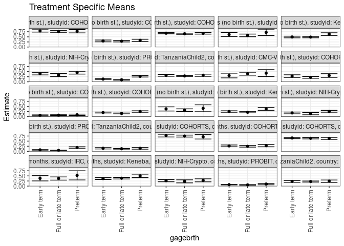

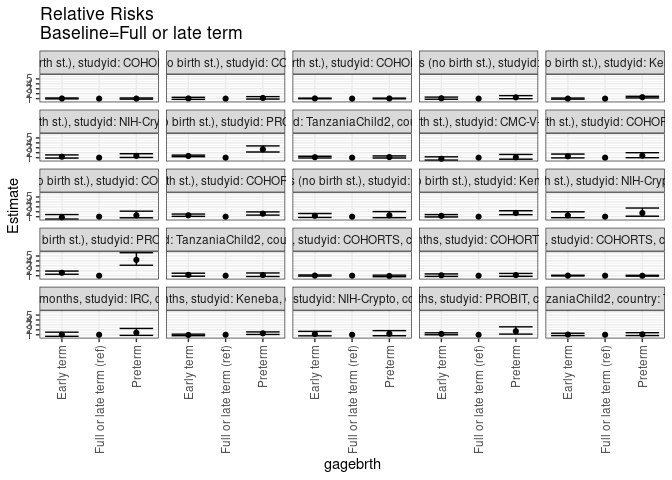

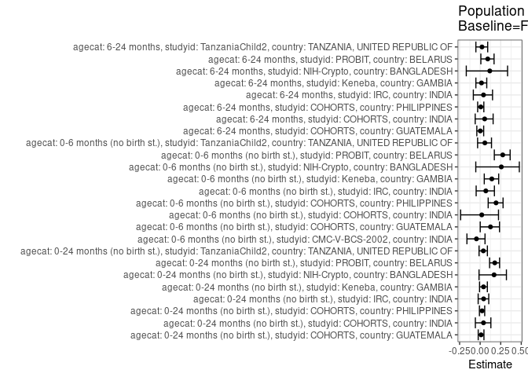

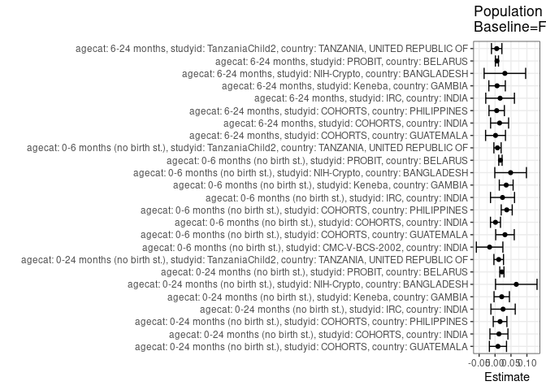

## Results Table

### Parameter: TSM

| agecat | studyid | country | intervention_level | baseline_level | estimate | ci_lower | ci_upper |
| --- | --- | --- | --- | --- | --- | --- | --- |
| 0-24 months (no birth st.) | COHORTS | GUATEMALA | Full or late term | NA | 0.7632242 | 0.7213775 | 0.8050708 |
| 0-24 months (no birth st.) | COHORTS | GUATEMALA | Preterm | NA | 0.7745098 | 0.6933505 | 0.8556691 |
| 0-24 months (no birth st.) | COHORTS | GUATEMALA | Early term | NA | 0.7897436 | 0.7325086 | 0.8469786 |
| 0-24 months (no birth st.) | COHORTS | INDIA | Full or late term | NA | 0.2882883 | 0.2505882 | 0.3259884 |
| 0-24 months (no birth st.) | COHORTS | INDIA | Preterm | NA | 0.3271375 | 0.2710488 | 0.3832263 |
| 0-24 months (no birth st.) | COHORTS | INDIA | Early term | NA | 0.2995169 | 0.2553769 | 0.3436570 |
| 0-24 months (no birth st.) | COHORTS | PHILIPPINES | Full or late term | NA | 0.6504425 | 0.6226358 | 0.6782491 |
| 0-24 months (no birth st.) | COHORTS | PHILIPPINES | Preterm | NA | 0.6725664 | 0.6338647 | 0.7112680 |
| 0-24 months (no birth st.) | COHORTS | PHILIPPINES | Early term | NA | 0.6785404 | 0.6515544 | 0.7055264 |
| 0-24 months (no birth st.) | IRC | INDIA | Full or late term | NA | 0.5701357 | 0.5047709 | 0.6355006 |
| 0-24 months (no birth st.) | IRC | INDIA | Preterm | NA | 0.7187500 | 0.5627423 | 0.8747577 |
| 0-24 months (no birth st.) | IRC | INDIA | Early term | NA | 0.6136364 | 0.5117542 | 0.7155185 |
| 0-24 months (no birth st.) | Keneba | GAMBIA | Full or late term | NA | 0.4882280 | 0.4537297 | 0.5227264 |
| 0-24 months (no birth st.) | Keneba | GAMBIA | Preterm | NA | 0.6338028 | 0.5690840 | 0.6985216 |
| 0-24 months (no birth st.) | Keneba | GAMBIA | Early term | NA | 0.4919786 | 0.4505960 | 0.5333612 |
| 0-24 months (no birth st.) | NIH-Crypto | BANGLADESH | Full or late term | NA | 0.3269231 | 0.2532560 | 0.4005902 |
| 0-24 months (no birth st.) | NIH-Crypto | BANGLADESH | Preterm | NA | 0.4472362 | 0.3781020 | 0.5163703 |
| 0-24 months (no birth st.) | NIH-Crypto | BANGLADESH | Early term | NA | 0.3926174 | 0.3371308 | 0.4481041 |
| 0-24 months (no birth st.) | PROBIT | BELARUS | Full or late term | NA | 0.0991274 | 0.0816595 | 0.1165953 |
| 0-24 months (no birth st.) | PROBIT | BELARUS | Preterm | NA | 0.2672566 | 0.2331054 | 0.3014079 |
| 0-24 months (no birth st.) | PROBIT | BELARUS | Early term | NA | 0.1338593 | 0.1161540 | 0.1515646 |
| 0-24 months (no birth st.) | TanzaniaChild2 | TANZANIA, UNITED REPUBLIC OF | Full or late term | NA | 0.2864701 | 0.2621023 | 0.3108380 |
| 0-24 months (no birth st.) | TanzaniaChild2 | TANZANIA, UNITED REPUBLIC OF | Preterm | NA | 0.3222591 | 0.2694508 | 0.3750675 |
| 0-24 months (no birth st.) | TanzaniaChild2 | TANZANIA, UNITED REPUBLIC OF | Early term | NA | 0.3144654 | 0.2727887 | 0.3561421 |
| 0-6 months (no birth st.) | CMC-V-BCS-2002 | INDIA | Full or late term | NA | 0.3966480 | 0.3248515 | 0.4684446 |
| 0-6 months (no birth st.) | CMC-V-BCS-2002 | INDIA | Preterm | NA | 0.4242424 | 0.2553104 | 0.5931744 |
| 0-6 months (no birth st.) | CMC-V-BCS-2002 | INDIA | Early term | NA | 0.3064516 | 0.1914866 | 0.4214166 |
| 0-6 months (no birth st.) | COHORTS | GUATEMALA | Full or late term | NA | 0.2169312 | 0.1753509 | 0.2585116 |
| 0-6 months (no birth st.) | COHORTS | GUATEMALA | Preterm | NA | 0.3069307 | 0.2169145 | 0.3969469 |
| 0-6 months (no birth st.) | COHORTS | GUATEMALA | Early term | NA | 0.2789474 | 0.2151297 | 0.3427650 |
| 0-6 months (no birth st.) | COHORTS | INDIA | Full or late term | NA | 0.0673953 | 0.0464154 | 0.0883752 |
| 0-6 months (no birth st.) | COHORTS | INDIA | Preterm | NA | 0.0867925 | 0.0528824 | 0.1207025 |
| 0-6 months (no birth st.) | COHORTS | INDIA | Early term | NA | 0.0588235 | 0.0359830 | 0.0816641 |
| 0-6 months (no birth st.) | COHORTS | PHILIPPINES | Full or late term | NA | 0.1530973 | 0.1320990 | 0.1740957 |
| 0-6 months (no birth st.) | COHORTS | PHILIPPINES | Preterm | NA | 0.2477876 | 0.2121827 | 0.2833925 |
| 0-6 months (no birth st.) | COHORTS | PHILIPPINES | Early term | NA | 0.1972198 | 0.1742287 | 0.2202109 |
| 0-6 months (no birth st.) | IRC | INDIA | Full or late term | NA | 0.3167421 | 0.2553185 | 0.3781656 |
| 0-6 months (no birth st.) | IRC | INDIA | Preterm | NA | 0.4062500 | 0.2358344 | 0.5766656 |
| 0-6 months (no birth st.) | IRC | INDIA | Early term | NA | 0.3750000 | 0.2737022 | 0.4762978 |
| 0-6 months (no birth st.) | Keneba | GAMBIA | Full or late term | NA | 0.2116402 | 0.1825134 | 0.2407670 |
| 0-6 months (no birth st.) | Keneba | GAMBIA | Preterm | NA | 0.3737864 | 0.3076969 | 0.4398759 |
| 0-6 months (no birth st.) | Keneba | GAMBIA | Early term | NA | 0.2472119 | 0.2107472 | 0.2836766 |
| 0-6 months (no birth st.) | NIH-Crypto | BANGLADESH | Full or late term | NA | 0.1410256 | 0.0863671 | 0.1956841 |
| 0-6 months (no birth st.) | NIH-Crypto | BANGLADESH | Preterm | NA | 0.2462312 | 0.1863287 | 0.3061337 |
| 0-6 months (no birth st.) | NIH-Crypto | BANGLADESH | Early term | NA | 0.1778523 | 0.1344036 | 0.2213011 |
| 0-6 months (no birth st.) | PROBIT | BELARUS | Full or late term | NA | 0.0445660 | 0.0328524 | 0.0562795 |
| 0-6 months (no birth st.) | PROBIT | BELARUS | Preterm | NA | 0.1876106 | 0.1531758 | 0.2220454 |
| 0-6 months (no birth st.) | PROBIT | BELARUS | Early term | NA | 0.0711468 | 0.0588139 | 0.0834796 |
| 0-6 months (no birth st.) | TanzaniaChild2 | TANZANIA, UNITED REPUBLIC OF | Full or late term | NA | 0.1269841 | 0.1090386 | 0.1449297 |
| 0-6 months (no birth st.) | TanzaniaChild2 | TANZANIA, UNITED REPUBLIC OF | Preterm | NA | 0.1461794 | 0.1062590 | 0.1860998 |
| 0-6 months (no birth st.) | TanzaniaChild2 | TANZANIA, UNITED REPUBLIC OF | Early term | NA | 0.1488470 | 0.1168973 | 0.1807966 |
| 6-24 months | COHORTS | GUATEMALA | Full or late term | NA | 0.7475410 | 0.6987398 | 0.7963422 |
| 6-24 months | COHORTS | GUATEMALA | Preterm | NA | 0.7101449 | 0.6029912 | 0.8172986 |
| 6-24 months | COHORTS | GUATEMALA | Early term | NA | 0.7708333 | 0.7021198 | 0.8395469 |
| 6-24 months | COHORTS | INDIA | Full or late term | NA | 0.2455446 | 0.2079886 | 0.2831005 |
| 6-24 months | COHORTS | INDIA | Preterm | NA | 0.2784810 | 0.2213871 | 0.3355749 |
| 6-24 months | COHORTS | INDIA | Early term | NA | 0.2671958 | 0.2225680 | 0.3118235 |
| 6-24 months | COHORTS | PHILIPPINES | Full or late term | NA | 0.6393629 | 0.6076113 | 0.6711145 |
| 6-24 months | COHORTS | PHILIPPINES | Preterm | NA | 0.6366048 | 0.5880418 | 0.6851677 |
| 6-24 months | COHORTS | PHILIPPINES | Early term | NA | 0.6533019 | 0.6212624 | 0.6853414 |
| 6-24 months | IRC | INDIA | Full or late term | NA | 0.3708609 | 0.2936452 | 0.4480766 |
| 6-24 months | IRC | INDIA | Preterm | NA | 0.5263158 | 0.3013035 | 0.7513281 |
| 6-24 months | IRC | INDIA | Early term | NA | 0.3818182 | 0.2531354 | 0.5105010 |
| 6-24 months | Keneba | GAMBIA | Full or late term | NA | 0.3853354 | 0.3476444 | 0.4230264 |
| 6-24 months | Keneba | GAMBIA | Preterm | NA | 0.5000000 | 0.4146681 | 0.5853319 |
| 6-24 months | Keneba | GAMBIA | Early term | NA | 0.3680556 | 0.3225586 | 0.4135525 |
| 6-24 months | NIH-Crypto | BANGLADESH | Full or late term | NA | 0.2320000 | 0.1579292 | 0.3060708 |
| 6-24 months | NIH-Crypto | BANGLADESH | Preterm | NA | 0.2816901 | 0.2076316 | 0.3557487 |
| 6-24 months | NIH-Crypto | BANGLADESH | Early term | NA | 0.2677824 | 0.2115884 | 0.3239764 |
| 6-24 months | PROBIT | BELARUS | Full or late term | NA | 0.0583282 | 0.0447972 | 0.0718591 |
| 6-24 months | PROBIT | BELARUS | Preterm | NA | 0.1002227 | 0.0636763 | 0.1367691 |
| 6-24 months | PROBIT | BELARUS | Early term | NA | 0.0688463 | 0.0572497 | 0.0804429 |
| 6-24 months | TanzaniaChild2 | TANZANIA, UNITED REPUBLIC OF | Full or late term | NA | 0.2223393 | 0.1958749 | 0.2488037 |
| 6-24 months | TanzaniaChild2 | TANZANIA, UNITED REPUBLIC OF | Preterm | NA | 0.2420091 | 0.1852654 | 0.2987529 |
| 6-24 months | TanzaniaChild2 | TANZANIA, UNITED REPUBLIC OF | Early term | NA | 0.2323529 | 0.1874466 | 0.2772593 |

### Parameter: E(Y)

| agecat | studyid | country | intervention_level | baseline_level | estimate | ci_lower | ci_upper |
| --- | --- | --- | --- | --- | --- | --- | --- |
| 0-24 months (no birth st.) | COHORTS | GUATEMALA | NA | NA | 0.7723343 | 0.7411143 | 0.8035543 |
| 0-24 months (no birth st.) | COHORTS | INDIA | NA | NA | 0.3004847 | 0.2749357 | 0.3260336 |
| 0-24 months (no birth st.) | COHORTS | PHILIPPINES | NA | NA | 0.6661982 | 0.6488700 | 0.6835264 |
| 0-24 months (no birth st.) | IRC | INDIA | NA | NA | 0.5953079 | 0.5431354 | 0.6474804 |
| 0-24 months (no birth st.) | Keneba | GAMBIA | NA | NA | 0.5091714 | 0.4845214 | 0.5338214 |
| 0-24 months (no birth st.) | NIH-Crypto | BANGLADESH | NA | NA | 0.3935681 | 0.3560687 | 0.4310676 |
| 0-24 months (no birth st.) | PROBIT | BELARUS | NA | NA | 0.1205488 | 0.1047261 | 0.1363714 |
| 0-24 months (no birth st.) | TanzaniaChild2 | TANZANIA, UNITED REPUBLIC OF | NA | NA | 0.2979534 | 0.2783922 | 0.3175146 |
| 0-6 months (no birth st.) | CMC-V-BCS-2002 | INDIA | NA | NA | 0.3795620 | 0.3219972 | 0.4371269 |
| 0-6 months (no birth st.) | COHORTS | GUATEMALA | NA | NA | 0.2481315 | 0.2153770 | 0.2808861 |
| 0-6 months (no birth st.) | COHORTS | INDIA | NA | NA | 0.0687398 | 0.0545482 | 0.0829313 |
| 0-6 months (no birth st.) | COHORTS | PHILIPPINES | NA | NA | 0.1897400 | 0.1753322 | 0.2041478 |
| 0-6 months (no birth st.) | IRC | INDIA | NA | NA | 0.3401760 | 0.2898173 | 0.3905347 |
| 0-6 months (no birth st.) | Keneba | GAMBIA | NA | NA | 0.2466667 | 0.2248446 | 0.2684887 |
| 0-6 months (no birth st.) | NIH-Crypto | BANGLADESH | NA | NA | 0.1898928 | 0.1597870 | 0.2199986 |
| 0-6 months (no birth st.) | PROBIT | BELARUS | NA | NA | 0.0614448 | 0.0507274 | 0.0721623 |
| 0-6 months (no birth st.) | TanzaniaChild2 | TANZANIA, UNITED REPUBLIC OF | NA | NA | 0.1346978 | 0.1200961 | 0.1492994 |
| 6-24 months | COHORTS | GUATEMALA | NA | NA | 0.7490347 | 0.7116615 | 0.7864080 |
| 6-24 months | COHORTS | INDIA | NA | NA | 0.2598214 | 0.2341270 | 0.2855158 |
| 6-24 months | COHORTS | PHILIPPINES | NA | NA | 0.6444867 | 0.6240287 | 0.6649447 |
| 6-24 months | IRC | INDIA | NA | NA | 0.3866667 | 0.3228931 | 0.4504402 |
| 6-24 months | Keneba | GAMBIA | NA | NA | 0.3917012 | 0.3641291 | 0.4192734 |
| 6-24 months | NIH-Crypto | BANGLADESH | NA | NA | 0.2628458 | 0.2244546 | 0.3012371 |
| 6-24 months | PROBIT | BELARUS | NA | NA | 0.0642659 | 0.0526827 | 0.0758490 |
| 6-24 months | TanzaniaChild2 | TANZANIA, UNITED REPUBLIC OF | NA | NA | 0.2274536 | 0.2062895 | 0.2486177 |

### Parameter: RR

| agecat | studyid | country | intervention_level | baseline_level | estimate | ci_lower | ci_upper |
| --- | --- | --- | --- | --- | --- | --- | --- |
| 0-24 months (no birth st.) | COHORTS | GUATEMALA | Full or late term | Full or late term | 1.0000000 | 1.0000000 | 1.000000 |
| 0-24 months (no birth st.) | COHORTS | GUATEMALA | Preterm | Full or late term | 1.0147868 | 0.9015976 | 1.142186 |
| 0-24 months (no birth st.) | COHORTS | GUATEMALA | Early term | Full or late term | 1.0347466 | 0.9448587 | 1.133186 |
| 0-24 months (no birth st.) | COHORTS | INDIA | Full or late term | Full or late term | 1.0000000 | 1.0000000 | 1.000000 |
| 0-24 months (no birth st.) | COHORTS | INDIA | Preterm | Full or late term | 1.1347584 | 0.9146506 | 1.407834 |
| 0-24 months (no birth st.) | COHORTS | INDIA | Early term | Full or late term | 1.0389493 | 0.8531526 | 1.265208 |
| 0-24 months (no birth st.) | COHORTS | PHILIPPINES | Full or late term | Full or late term | 1.0000000 | 1.0000000 | 1.000000 |
| 0-24 months (no birth st.) | COHORTS | PHILIPPINES | Preterm | Full or late term | 1.0340136 | 0.9624842 | 1.110859 |
| 0-24 months (no birth st.) | COHORTS | PHILIPPINES | Early term | Full or late term | 1.0431982 | 0.9840309 | 1.105923 |
| 0-24 months (no birth st.) | IRC | INDIA | Full or late term | Full or late term | 1.0000000 | 1.0000000 | 1.000000 |
| 0-24 months (no birth st.) | IRC | INDIA | Preterm | Full or late term | 1.2606647 | 0.9862620 | 1.611413 |
| 0-24 months (no birth st.) | IRC | INDIA | Early term | Full or late term | 1.0762987 | 0.8796426 | 1.316920 |
| 0-24 months (no birth st.) | Keneba | GAMBIA | Full or late term | Full or late term | 1.0000000 | 1.0000000 | 1.000000 |
| 0-24 months (no birth st.) | Keneba | GAMBIA | Preterm | Full or late term | 1.2981697 | 1.1465750 | 1.469808 |
| 0-24 months (no birth st.) | Keneba | GAMBIA | Early term | Full or late term | 1.0076821 | 0.9028467 | 1.124691 |
| 0-24 months (no birth st.) | NIH-Crypto | BANGLADESH | Full or late term | Full or late term | 1.0000000 | 1.0000000 | 1.000000 |
| 0-24 months (no birth st.) | NIH-Crypto | BANGLADESH | Preterm | Full or late term | 1.3680166 | 1.0409169 | 1.797905 |
| 0-24 months (no birth st.) | NIH-Crypto | BANGLADESH | Early term | Full or late term | 1.2009475 | 0.9204661 | 1.566896 |
| 0-24 months (no birth st.) | PROBIT | BELARUS | Full or late term | Full or late term | 1.0000000 | 1.0000000 | 1.000000 |
| 0-24 months (no birth st.) | PROBIT | BELARUS | Preterm | Full or late term | 2.6960925 | 2.1496154 | 3.381495 |
| 0-24 months (no birth st.) | PROBIT | BELARUS | Early term | Full or late term | 1.3503764 | 1.2019829 | 1.517090 |
| 0-24 months (no birth st.) | TanzaniaChild2 | TANZANIA, UNITED REPUBLIC OF | Full or late term | Full or late term | 1.0000000 | 1.0000000 | 1.000000 |
| 0-24 months (no birth st.) | TanzaniaChild2 | TANZANIA, UNITED REPUBLIC OF | Preterm | Full or late term | 1.1249310 | 0.9352796 | 1.353039 |
| 0-24 months (no birth st.) | TanzaniaChild2 | TANZANIA, UNITED REPUBLIC OF | Early term | Full or late term | 1.0977249 | 0.9377785 | 1.284952 |
| 0-6 months (no birth st.) | CMC-V-BCS-2002 | INDIA | Full or late term | Full or late term | 1.0000000 | 1.0000000 | 1.000000 |
| 0-6 months (no birth st.) | CMC-V-BCS-2002 | INDIA | Preterm | Full or late term | 1.0695689 | 0.6906300 | 1.656426 |
| 0-6 months (no birth st.) | CMC-V-BCS-2002 | INDIA | Early term | Full or late term | 0.7726034 | 0.5093991 | 1.171804 |
| 0-6 months (no birth st.) | COHORTS | GUATEMALA | Full or late term | Full or late term | 1.0000000 | 1.0000000 | 1.000000 |
| 0-6 months (no birth st.) | COHORTS | GUATEMALA | Preterm | Full or late term | 1.4148756 | 0.9966877 | 2.008526 |
| 0-6 months (no birth st.) | COHORTS | GUATEMALA | Early term | Full or late term | 1.2858793 | 0.9540687 | 1.733089 |
| 0-6 months (no birth st.) | COHORTS | INDIA | Full or late term | Full or late term | 1.0000000 | 1.0000000 | 1.000000 |
| 0-6 months (no birth st.) | COHORTS | INDIA | Preterm | Full or late term | 1.2878123 | 0.7814462 | 2.122297 |
| 0-6 months (no birth st.) | COHORTS | INDIA | Early term | Full or late term | 0.8728140 | 0.5306240 | 1.435676 |
| 0-6 months (no birth st.) | COHORTS | PHILIPPINES | Full or late term | Full or late term | 1.0000000 | 1.0000000 | 1.000000 |
| 0-6 months (no birth st.) | COHORTS | PHILIPPINES | Preterm | Full or late term | 1.6184971 | 1.3269120 | 1.974157 |
| 0-6 months (no birth st.) | COHORTS | PHILIPPINES | Early term | Full or late term | 1.2881988 | 1.0759879 | 1.542263 |
| 0-6 months (no birth st.) | IRC | INDIA | Full or late term | Full or late term | 1.0000000 | 1.0000000 | 1.000000 |
| 0-6 months (no birth st.) | IRC | INDIA | Preterm | Full or late term | 1.2825893 | 0.8079468 | 2.036069 |
| 0-6 months (no birth st.) | IRC | INDIA | Early term | Full or late term | 1.1839286 | 0.8490052 | 1.650976 |
| 0-6 months (no birth st.) | Keneba | GAMBIA | Full or late term | Full or late term | 1.0000000 | 1.0000000 | 1.000000 |
| 0-6 months (no birth st.) | Keneba | GAMBIA | Preterm | Full or late term | 1.7661408 | 1.4116195 | 2.209698 |
| 0-6 months (no birth st.) | Keneba | GAMBIA | Early term | Full or late term | 1.1680762 | 0.9546801 | 1.429172 |
| 0-6 months (no birth st.) | NIH-Crypto | BANGLADESH | Full or late term | Full or late term | 1.0000000 | 1.0000000 | 1.000000 |
| 0-6 months (no birth st.) | NIH-Crypto | BANGLADESH | Preterm | Full or late term | 1.7460027 | 1.1048676 | 2.759177 |
| 0-6 months (no birth st.) | NIH-Crypto | BANGLADESH | Early term | Full or late term | 1.2611348 | 0.7976110 | 1.994031 |
| 0-6 months (no birth st.) | PROBIT | BELARUS | Full or late term | Full or late term | 1.0000000 | 1.0000000 | 1.000000 |
| 0-6 months (no birth st.) | PROBIT | BELARUS | Preterm | Full or late term | 4.2097276 | 3.1240473 | 5.672707 |
| 0-6 months (no birth st.) | PROBIT | BELARUS | Early term | Full or late term | 1.5964368 | 1.3093384 | 1.946487 |
| 0-6 months (no birth st.) | TanzaniaChild2 | TANZANIA, UNITED REPUBLIC OF | Full or late term | Full or late term | 1.0000000 | 1.0000000 | 1.000000 |
| 0-6 months (no birth st.) | TanzaniaChild2 | TANZANIA, UNITED REPUBLIC OF | Preterm | Full or late term | 1.1511628 | 0.8464378 | 1.565592 |
| 0-6 months (no birth st.) | TanzaniaChild2 | TANZANIA, UNITED REPUBLIC OF | Early term | Full or late term | 1.1721698 | 0.9065253 | 1.515658 |
| 6-24 months | COHORTS | GUATEMALA | Full or late term | Full or late term | 1.0000000 | 1.0000000 | 1.000000 |
| 6-24 months | COHORTS | GUATEMALA | Preterm | Full or late term | 0.9499746 | 0.8059555 | 1.119729 |
| 6-24 months | COHORTS | GUATEMALA | Early term | Full or late term | 1.0311586 | 0.9232945 | 1.151624 |
| 6-24 months | COHORTS | INDIA | Full or late term | Full or late term | 1.0000000 | 1.0000000 | 1.000000 |
| 6-24 months | COHORTS | INDIA | Preterm | Full or late term | 1.1341364 | 0.8781708 | 1.464710 |
| 6-24 months | COHORTS | INDIA | Early term | Full or late term | 1.0881763 | 0.8676473 | 1.364757 |
| 6-24 months | COHORTS | PHILIPPINES | Full or late term | Full or late term | 1.0000000 | 1.0000000 | 1.000000 |
| 6-24 months | COHORTS | PHILIPPINES | Preterm | Full or late term | 0.9956861 | 0.9090564 | 1.090571 |
| 6-24 months | COHORTS | PHILIPPINES | Early term | Full or late term | 1.0218013 | 0.9529161 | 1.095666 |
| 6-24 months | IRC | INDIA | Full or late term | Full or late term | 1.0000000 | 1.0000000 | 1.000000 |
| 6-24 months | IRC | INDIA | Preterm | Full or late term | 1.4191729 | 0.8820972 | 2.283254 |
| 6-24 months | IRC | INDIA | Early term | Full or late term | 1.0295455 | 0.6927854 | 1.530003 |
| 6-24 months | Keneba | GAMBIA | Full or late term | Full or late term | 1.0000000 | 1.0000000 | 1.000000 |
| 6-24 months | Keneba | GAMBIA | Preterm | Full or late term | 1.2975709 | 1.0658653 | 1.579646 |
| 6-24 months | Keneba | GAMBIA | Early term | Full or late term | 0.9551563 | 0.8158597 | 1.118236 |
| 6-24 months | NIH-Crypto | BANGLADESH | Full or late term | Full or late term | 1.0000000 | 1.0000000 | 1.000000 |
| 6-24 months | NIH-Crypto | BANGLADESH | Preterm | Full or late term | 1.2141816 | 0.8029065 | 1.836125 |
| 6-24 months | NIH-Crypto | BANGLADESH | Early term | Full or late term | 1.1542346 | 0.7877113 | 1.691302 |
| 6-24 months | PROBIT | BELARUS | Full or late term | Full or late term | 1.0000000 | 1.0000000 | 1.000000 |
| 6-24 months | PROBIT | BELARUS | Preterm | Full or late term | 1.7182557 | 1.1329207 | 2.606010 |
| 6-24 months | PROBIT | BELARUS | Early term | Full or late term | 1.1803270 | 1.0038777 | 1.387790 |
| 6-24 months | TanzaniaChild2 | TANZANIA, UNITED REPUBLIC OF | Full or late term | Full or late term | 1.0000000 | 1.0000000 | 1.000000 |
| 6-24 months | TanzaniaChild2 | TANZANIA, UNITED REPUBLIC OF | Preterm | Full or late term | 1.0884676 | 0.8367914 | 1.415839 |
| 6-24 months | TanzaniaChild2 | TANZANIA, UNITED REPUBLIC OF | Early term | Full or late term | 1.0450376 | 0.8328289 | 1.311318 |

### Parameter: PAR

| agecat | studyid | country | intervention_level | baseline_level | estimate | ci_lower | ci_upper |
| --- | --- | --- | --- | --- | --- | --- | --- |
| 0-24 months (no birth st.) | COHORTS | GUATEMALA | Full or late term | NA | 0.0091101 | -0.0177667 | 0.0359869 |
| 0-24 months (no birth st.) | COHORTS | INDIA | Full or late term | NA | 0.0121964 | -0.0160826 | 0.0404753 |
| 0-24 months (no birth st.) | COHORTS | PHILIPPINES | Full or late term | NA | 0.0157557 | -0.0056796 | 0.0371910 |
| 0-24 months (no birth st.) | IRC | INDIA | Full or late term | NA | 0.0251722 | -0.0129918 | 0.0633362 |
| 0-24 months (no birth st.) | Keneba | GAMBIA | Full or late term | NA | 0.0209434 | -0.0031974 | 0.0450842 |
| 0-24 months (no birth st.) | NIH-Crypto | BANGLADESH | Full or late term | NA | 0.0666451 | 0.0015287 | 0.1317614 |
| 0-24 months (no birth st.) | PROBIT | BELARUS | Full or late term | NA | 0.0214214 | 0.0148230 | 0.0280197 |
| 0-24 months (no birth st.) | TanzaniaChild2 | TANZANIA, UNITED REPUBLIC OF | Full or late term | NA | 0.0114832 | -0.0036367 | 0.0266031 |
| 0-6 months (no birth st.) | CMC-V-BCS-2002 | INDIA | Full or late term | NA | -0.0170860 | -0.0587204 | 0.0245484 |
| 0-6 months (no birth st.) | COHORTS | GUATEMALA | Full or late term | NA | 0.0312003 | 0.0020795 | 0.0603212 |
| 0-6 months (no birth st.) | COHORTS | INDIA | Full or late term | NA | 0.0013445 | -0.0143419 | 0.0170309 |
| 0-6 months (no birth st.) | COHORTS | PHILIPPINES | Full or late term | NA | 0.0366426 | 0.0193691 | 0.0539162 |
| 0-6 months (no birth st.) | IRC | INDIA | Full or late term | NA | 0.0234339 | -0.0142295 | 0.0610972 |
| 0-6 months (no birth st.) | Keneba | GAMBIA | Full or late term | NA | 0.0350265 | 0.0133604 | 0.0566925 |
| 0-6 months (no birth st.) | NIH-Crypto | BANGLADESH | Full or late term | NA | 0.0488672 | -0.0007964 | 0.0985308 |
| 0-6 months (no birth st.) | PROBIT | BELARUS | Full or late term | NA | 0.0168789 | 0.0116430 | 0.0221148 |
| 0-6 months (no birth st.) | TanzaniaChild2 | TANZANIA, UNITED REPUBLIC OF | Full or late term | NA | 0.0077136 | -0.0036737 | 0.0191009 |
| 6-24 months | COHORTS | GUATEMALA | Full or late term | NA | 0.0014938 | -0.0297117 | 0.0326992 |
| 6-24 months | COHORTS | INDIA | Full or late term | NA | 0.0142769 | -0.0139849 | 0.0425387 |
| 6-24 months | COHORTS | PHILIPPINES | Full or late term | NA | 0.0051238 | -0.0190490 | 0.0292965 |
| 6-24 months | IRC | INDIA | Full or late term | NA | 0.0158057 | -0.0292126 | 0.0608240 |
| 6-24 months | Keneba | GAMBIA | Full or late term | NA | 0.0063658 | -0.0195078 | 0.0322395 |
| 6-24 months | NIH-Crypto | BANGLADESH | Full or late term | NA | 0.0308458 | -0.0343436 | 0.0960353 |
| 6-24 months | PROBIT | BELARUS | Full or late term | NA | 0.0059377 | 0.0011419 | 0.0107335 |
| 6-24 months | TanzaniaChild2 | TANZANIA, UNITED REPUBLIC OF | Full or late term | NA | 0.0051143 | -0.0112195 | 0.0214480 |

### Parameter: PAF

| agecat | studyid | country | intervention_level | baseline_level | estimate | ci_lower | ci_upper |
| --- | --- | --- | --- | --- | --- | --- | --- |
| 0-24 months (no birth st.) | COHORTS | GUATEMALA | Full or late term | NA | 0.0117956 | -0.0236432 | 0.0460074 |
| 0-24 months (no birth st.) | COHORTS | INDIA | Full or late term | NA | 0.0405890 | -0.0582805 | 0.1302216 |
| 0-24 months (no birth st.) | COHORTS | PHILIPPINES | Full or late term | NA | 0.0236502 | -0.0090791 | 0.0553178 |
| 0-24 months (no birth st.) | IRC | INDIA | Full or late term | NA | 0.0422843 | -0.0242259 | 0.1044755 |
| 0-24 months (no birth st.) | Keneba | GAMBIA | Full or late term | NA | 0.0411323 | -0.0075148 | 0.0874306 |
| 0-24 months (no birth st.) | NIH-Crypto | BANGLADESH | Full or late term | NA | 0.1693355 | -0.0138187 | 0.3194015 |
| 0-24 months (no birth st.) | PROBIT | BELARUS | Full or late term | NA | 0.1776987 | 0.1147654 | 0.2361580 |
| 0-24 months (no birth st.) | TanzaniaChild2 | TANZANIA, UNITED REPUBLIC OF | Full or late term | NA | 0.0385403 | -0.0135563 | 0.0879592 |
| 0-6 months (no birth st.) | CMC-V-BCS-2002 | INDIA | Full or late term | NA | -0.0450150 | -0.1607351 | 0.0591683 |
| 0-6 months (no birth st.) | COHORTS | GUATEMALA | Full or late term | NA | 0.1257411 | 0.0007075 | 0.2351302 |
| 0-6 months (no birth st.) | COHORTS | INDIA | Full or late term | NA | 0.0195594 | -0.2373454 | 0.2231241 |
| 0-6 months (no birth st.) | COHORTS | PHILIPPINES | Full or late term | NA | 0.1931203 | 0.0975734 | 0.2785509 |
| 0-6 months (no birth st.) | IRC | INDIA | Full or late term | NA | 0.0688875 | -0.0486600 | 0.1732588 |
| 0-6 months (no birth st.) | Keneba | GAMBIA | Full or late term | NA | 0.1419991 | 0.0499475 | 0.2251318 |
| 0-6 months (no birth st.) | NIH-Crypto | BANGLADESH | Full or late term | NA | 0.2573408 | -0.0532049 | 0.4763196 |
| 0-6 months (no birth st.) | PROBIT | BELARUS | Full or late term | NA | 0.2746996 | 0.1722228 | 0.3644899 |
| 0-6 months (no birth st.) | TanzaniaChild2 | TANZANIA, UNITED REPUBLIC OF | Full or late term | NA | 0.0572663 | -0.0310035 | 0.1379788 |
| 6-24 months | COHORTS | GUATEMALA | Full or late term | NA | 0.0019943 | -0.0405490 | 0.0427981 |
| 6-24 months | COHORTS | INDIA | Full or late term | NA | 0.0549488 | -0.0602810 | 0.1576556 |
| 6-24 months | COHORTS | PHILIPPINES | Full or late term | NA | 0.0079502 | -0.0302771 | 0.0447591 |
| 6-24 months | IRC | INDIA | Full or late term | NA | 0.0408769 | -0.0829571 | 0.1505508 |
| 6-24 months | Keneba | GAMBIA | Full or late term | NA | 0.0162518 | -0.0520738 | 0.0801400 |
| 6-24 months | NIH-Crypto | BANGLADESH | Full or late term | NA | 0.1173534 | -0.1687207 | 0.3334036 |
| 6-24 months | PROBIT | BELARUS | Full or late term | NA | 0.0923925 | 0.0085839 | 0.1691164 |
| 6-24 months | TanzaniaChild2 | TANZANIA, UNITED REPUBLIC OF | Full or late term | NA | 0.0224849 | -0.0520160 | 0.0917099 |